# 随机模拟方法与应用导论 作业三

陈稼霖 45875852

2019-10-01

# 3.5 (Relating age and wage in the twins dataset)

The variables `AGE` and `HRWAGEL` contain the age (in years) and hourly wage (in dollars) of twin 1.

1. Using two applications of the `cut` function, create a categorized version of `AGE` using the breakpoints $30$, $40$, and $50$, and a categorized version of `HRWAGEL` using the same breakpoints as in Section 3.3.
2. Using the categorized versions of AGE and HRWAGEL, construct a contingency table of the two variables using the function `table`.
3. Use the `prop.table` function to find the proportions of twins in each age class that have the different wage groups.
4. Construct a suitable graph to show how the wage distribution depends on the age of the twin.
5. Use the conditional proportions in part (c) and the graph in part (d) to explain the relationship between age and wage of the twins.
1. 首先读取数据文件`twins.dat.txt`，用`cut`函数根据断点$30$，$40$和$50$分割变量`AGE`并展示结果

```r
twn = read.table('twins.dat.txt',header = TRUE,sep = ',',na.strings = '.')
c.age = cut(twn$AGE,breaks = c(0,30,40,50,80))
c.age
```

```
##   [1] (30,40] (50,80] (40,50] (30,40] (30,40] (50,80] (30,40] (50,80]
##   [9] (0,30]  (40,50] (50,80] (30,40] (30,40] (40,50] (30,40] (30,40]
##  [17] (0,30]  (0,30]  (30,40] (30,40] (0,30]  (0,30]  (30,40] (0,30]
##  [25] (0,30]  (30,40] (30,40] (0,30]  (40,50] (40,50] (50,80] (0,30]
##  [33] (50,80] (30,40] (50,80] (40,50] (30,40] (0,30]  (30,40] (50,80]
##  [41] (0,30]  (0,30]  (30,40] (40,50] (0,30]  (40,50] (50,80] (30,40]
##  [49] (50,80] (30,40] (50,80] (0,30]  (30,40] (50,80] (50,80] (40,50]
##  [57] (0,30]  (0,30]  (0,30]  (0,30]  (50,80] (50,80] (40,50] (30,40]
##  [65] (0,30]  (30,40] (50,80] (0,30]  (30,40] (30,40] (30,40] (30,40]
##  [73] (30,40] (30,40] (30,40] (0,30]  (30,40] (30,40] (40,50] (30,40]
##  [81] (40,50] (30,40] (0,30]  (40,50] (50,80] (0,30]  (50,80] (40,50]
##  [89] (0,30]  (50,80] (50,80] (50,80] (40,50] (30,40] (50,80] (0,30]
##  [97] (30,40] (50,80] (40,50] (0,30]  (50,80] (0,30]  (50,80] (40,50]
## [105] (30,40] (40,50] (30,40] (0,30]  (30,40] (30,40] (30,40] (30,40]
## [113] (50,80] (30,40] (0,30]  (40,50] (30,40] (0,30]  (0,30]  (40,50]
## [121] (50,80] (50,80] (30,40] (30,40] (30,40] (30,40] (30,40] (40,50]
## [129] (40,50] (30,40] (30,40] (0,30]  (0,30]  (0,30]  (40,50] (30,40]
## [137] (0,30]  (30,40] (0,30]  (40,50] (40,50] (50,80] (40,50] (0,30]
## [145] (30,40] (30,40] (0,30]  (50,80] (50,80] (50,80] (50,80] (0,30]
## [153] (50,80] (0,30]  (30,40] (0,30]  (0,30]  (50,80] (40,50] (30,40]
## [161] (40,50] (30,40] (50,80] (0,30]  (30,40] (50,80] (30,40] (0,30]
## [169] (0,30]  (30,40] (0,30]  (30,40] (40,50] (0,30]  (30,40] (40,50]
## [177] (0,30]  (30,40] (40,50] (0,30]  (40,50] (0,30]  (0,30]
## Levels: (0,30] (30,40] (40,50] (50,80]
```

然后用`cut`函数根据3.3节中的断点———`0,7,13,20,150`———分割变量`HRWAGEL`并展示结果

```r
c.wage = cut(twn$HRWAGEL,breaks = c(0,7,13,20,150))
c.wage
```

```
##   [1] (7,13]   (7,13]   (7,13]   (13,20]  (13,20]  <NA>     (7,13]
##   [8] <NA>     (13,20]  (7,13]   (13,20]  (7,13]   (20,150] (20,150]
##  [15] (7,13]   <NA>     (0,7]    <NA>     (7,13]   (7,13]   <NA>
##  [22] (13,20]  (13,20]  (7,13]   <NA>     <NA>     (13,20]  (7,13]
##  [29] (0,7]    (20,150] (0,7]    (0,7]    <NA>     (7,13]   (7,13]
##  [36] (20,150] (20,150] (0,7]    (7,13]   (13,20]  (13,20]  (0,7]
##  [43] (13,20]  (20,150] (0,7]    (20,150] (20,150] (7,13]   (7,13]
##  [50] (0,7]    (20,150] (7,13]   (7,13]   (7,13]   (13,20]  (20,150]
##  [57] (7,13]   (0,7]    (0,7]    (7,13]   (13,20]  (7,13]   (13,20]
##  [64] (13,20]  (0,7]    (7,13]   <NA>     (0,7]    (20,150] (0,7]
##  [71] (7,13]   (0,7]    (13,20]  (20,150] (0,7]    <NA>     (13,20]
##  [78] (0,7]    <NA>     (0,7]    (0,7]    (13,20]  (7,13]   (7,13]
##  [85] (7,13]   (7,13]   <NA>     (13,20]  (7,13]   (13,20]  <NA>
##  [92] <NA>     (7,13]   (7,13]   (13,20]  (0,7]    (7,13]   (7,13]
##  [99] (20,150] (0,7]    (7,13]   (7,13]   (7,13]   (13,20]  (7,13]
## [106] (20,150] (7,13]   <NA>     (7,13]   (0,7]    (0,7]    (0,7]
## [113] <NA>     (13,20]  (0,7]    (20,150] (13,20]  (0,7]    <NA>
## [120] (0,7]    <NA>     (20,150] (0,7]    (7,13]   (7,13]   (7,13]
## [127] (7,13]   (13,20]  (7,13]   (7,13]   (20,150] (0,7]    (7,13]
## [134] (7,13]   (20,150] (13,20]  (0,7]    (7,13]   (0,7]    (7,13]
## [141] (7,13]   (0,7]    (0,7]    (7,13]   (0,7]    (0,7]    (7,13]
## [148] (0,7]    (13,20]  <NA>     (0,7]    (7,13]   (0,7]    (13,20]
## [155] (0,7]    (7,13]   (0,7]    (0,7]    (13,20]  <NA>     (0,7]
## [162] (7,13]   (0,7]    (13,20]  (13,20]  <NA>     (13,20]  (0,7]
## [169] (7,13]   (7,13]   (13,20]  (13,20]  (0,7]    (0,7]    (7,13]
## [176] (13,20]  (0,7]    (20,150] (13,20]  (13,20]  (0,7]    (13,20]
## [183] (13,20]
## Levels: (0,7] (7,13] (13,20] (20,150]
```

2. 用`table`函数构建年龄和小时工资的相依表并展示

```r
T = table(c.age,c.wage)
T
```

```
##          c.wage
## c.age     (0,7] (7,13] (13,20] (20,150]
##   (0,30]     20     16       9        0
##   (30,40]    13     26      15        6
##   (40,50]     7      7       7       10
##   (50,80]     7      9       7        3
```

3. 用`prop.table`函数计算各年龄层次的工资分布情况

```r
P = prop.table(T,margin = 1)
P
```

```
##          c.wage
## c.age         (0,7]    (7,13]   (13,20]  (20,150]
##   (0,30]  0.4444444 0.3555556 0.2000000 0.0000000
##   (30,40] 0.2166667 0.4333333 0.2500000 0.1000000
##   (40,50] 0.2258065 0.2258065 0.2258065 0.3225806
##   (50,80] 0.2692308 0.3461538 0.2692308 0.1153846
```

4. 用`barplot`函数绘制工资分布随年龄变化的分段条形图

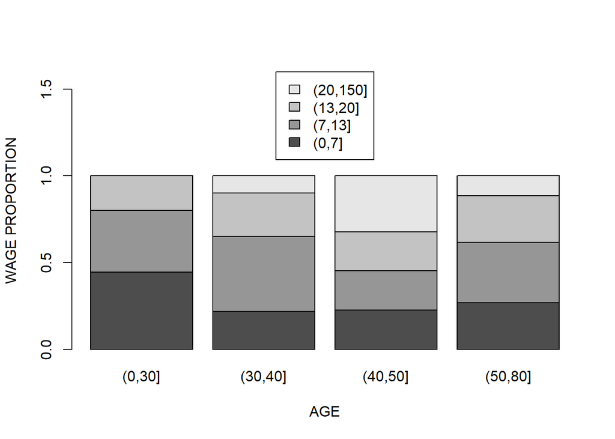

```r
barplot(t(P),ylim = c(0,1.6),ylab = 'WAGE PROPORTION',xlab = 'AGE'
        ,legend.text = dimnames(P)$c.wage,args.legend = list(x = 'top'))
```

5. 解释：由c中的条件比例和d中的分段条形图可见，双胞胎的工资随着年龄的增长先有一定程度的提高，这可能是由于随着学历的提高和工龄的增长，双胞胎的工作能力提高，随着年龄的进步增长，工资后下降，这可能是双胞胎由于年老，工作能力下降。